# Assignment 8 - Working With Textual Data

Ken Benoit and Slava Mikhaylov

Assignments for the course focus on practical aspects of the concepts covered in the lectures. Assignments are largely based on the material covered in James et al. (2013). You will start working on the assignment in the lab sessions after the lectures, but may need to finish them after class.

You will be asked to submit your assignments via Moodle by 7pm on the day of the class. We will subsequently open up solutions to the problem sets.

### Exercise summary

This exercise is designed to get you working with quanteda. The focus will be on exploring the package and getting some texts into the **corpus** object format. quanteda package has several functions for creating a corpus of texts which we will use in this exercise.

1. Getting Started.

   You can use R or Rstudio for these exercises. You will first need to install the package,  
   using the commands below. Also see the instructions for installation from the dev branch page of http://github.com/kbenoit/quanteda.

   ```r
   # needs the devtools package for this to work
   if (!require(devtools)) install.packages("devtools", dependencies=TRUE)
   # PREFERABLY: install the latest version from GitHub
   # see the installation instructions on http://github.com/kbenoit/quanteda
   devtools::install_github("kbenoit/quanteda")
   # and quantedaData
   devtools::install_github("quantedaData", username="kbenoit")
   ```

2. Exploring **quanteda** functions.

   Look at the Quick Start vignette, and browse the manual for quanteda. You can use `example()` function for any function in the package, to run the examples and see how the function works. Of course you should also browse the documentation, especially `?corpus` to see the structure and operations of how to construct a corpus.

   ```r
   help(package = "quanteda")
   ```

3. Making a corpus and corpus structure
   1. From a vector of texts already in memory.

      The simplest way to create a corpus is to use a vector of texts already present in R’s global environment. Some text and corpus objects are built into the package, for example `inaugTexts` is the UTF-8 encoded set of 57 presidential inaugural addresses. Try using `corpus()` on this set of texts to create a corpus.

      Once you have constructed this corpus, use the `summary()` method to see a brief description of the corpus. The names of the character vector `inaugTexts` should have become the document names.

      ```r
      str(inaugTexts)
      ```

      ```
      ##  Named chr [1:57] "Fellow-Citizens of the Senate and of the House of Representatives:\n\nAmong the vicissitudes incident to life no event could ha"| __truncated__ ...
      ##  - attr(*, "names")= chr [1:57] "1789-Washington" "1793-Washington" "1797-Adams" "1801-Jefferson" ...
      ```

      ```r
      myInaugCorpus <- corpus(inaugTexts, notes = "Corpus created in lab")
      summary(myInaugCorpus)
      ```

      ```
      ## Corpus consisting of 57 documents.
      ##
      ##             Text Types Tokens Sentences
      ##  1789-Washington   595   1430        24
      ##  1793-Washington    90    135         4
      ##       1797-Adams   794   2318        37
      ##   1801-Jefferson   681   1726        42
      ##   1805-Jefferson   776   2166        45
      ##     1809-Madison   520   1175        21
      ##     1813-Madison   518   1210        33
      ##      1817-Monroe   980   3370       121
      ##      1821-Monroe  1200   4470       131
      ##       1825-Adams   962   2915        74
      ##     1829-Jackson   500   1128        25
      ##     1833-Jackson   474   1176        30
      ##    1837-VanBuren  1252   3839        95
      ##    1841-Harrison  1806   8446       210
      ##        1845-Polk  1262   4803       153
      ##      1849-Taylor   480   1088        22
      ##      1853-Pierce  1115   3333       104
      ##    1857-Buchanan   892   2824        89
      ##     1861-Lincoln  1011   3634       138
      ##     1865-Lincoln   336    699        27
      ##       1869-Grant   464   1127        41
      ##       1873-Grant   522   1338        44
      ##       1877-Hayes   803   2484        59
      ##    1881-Garfield   973   2975       112
      ##   1885-Cleveland   645   1683        44
      ##    1889-Harrison  1300   4386       157
      ##   1893-Cleveland   797   2014        58
      ##    1897-McKinley  1187   3965       130
      ##    1901-McKinley   815   2212       100
      ##   1905-Roosevelt   384    984        33
      ##        1909-Taft  1376   5429       159
      ##      1913-Wilson   627   1699        68
      ##      1917-Wilson   524   1529        60
      ##     1921-Harding  1120   3327       149
      ##    1925-Coolidge  1160   4056       197
      ##      1929-Hoover   997   3558       171
      ##   1933-Roosevelt   708   1880        85
      ```

      [output cut: 9 more lines]

      ```
      ##       1973-Nixon   508   1802        69
      ##      1977-Carter   493   1224        53
      ##      1981-Reagan   844   2433       128
      ##      1985-Reagan   866   2564       125
      ##        1989-Bush   749   2317       143
      ##     1993-Clinton   600   1598        81
      ##     1997-Clinton   719   2157       112
      ##        2001-Bush   585   1584        97
      ##        2005-Bush   725   2071       101
      ##       2009-Obama   893   2390       112
      ##       2013-Obama   781   2097        90
      ##
      ## Source:  /Users/kbenoit/Dropbox/Classes/LSE Data Science/Ken_github/ME114/day8/* on x86_64 by kbenoit.
      ## Created: Wed Aug 26 09:55:14 2015.
      ## Notes:   Corpus created in lab.
      ```

   2. From a directory of text files.

      The `textfile()` function can read (almost) any set of files into an object that you can then call the corpus()`function on, to create a corpus. (See`?textfile` for an example.)

      Here you are encouraged to select any directory of plain text files of your own.  
      How did it work? Try using `docvars()` to assign a set of document-level variables. If you do not have a set of text files to work with, then you can use the UK 2010 manifesto texts on immigration, in the Day 8 folder, like this:

      ```r
      require(quanteda)
      manfiles <- textfile("https://github.com/kbenoit/ME114/raw/master/day8/UKimmigTexts.zip")
      mycorpus <- corpus(manfiles)
      ```

   3. From `.csv` or `.json` files — see the documentation with `?textfile`.

      Here you can try one of your own examples, or just file this in your mental catalogue for future reference.
4. Explore some phrases in the text.

   You can do this using the `kwic` (for “key-words-in-context”) to explore a specific word or phrase.

   ```r
   kwic(inaugCorpus, "terror", 3)
   ```

   ```
   ##                                                  preword      word
   ##    [1797-Adams, 1183]                    or violence, by   terror,
   ## [1933-Roosevelt, 100] nameless, unreasoning, unjustified    terror
   ## [1941-Roosevelt, 252]                    by a fatalistic   terror,
   ##   [1961-Kennedy, 763]               uncertain balance of   terror
   ##   [1961-Kennedy, 872]                     instead of its  terrors.
   ##    [1981-Reagan, 691]                 Americans from the  terror
   ##   [1981-Reagan, 1891]                 those who practice terrorism
   ##   [1997-Clinton, 929]                  the fanaticism of   terror.
   ##  [1997-Clinton, 1462]             strong defense against   terror
   ##    [2009-Obama, 1433]                   aims by inducing    terror
   ##                                          postword
   ##    [1797-Adams, 1183] intrigue, or venality,
   ## [1933-Roosevelt, 100] which paralyzes needed
   ## [1941-Roosevelt, 252] we proved that
   ##   [1961-Kennedy, 763] that stays the
   ##   [1961-Kennedy, 872] Together let us
   ##    [1981-Reagan, 691] of runaway living
   ##   [1981-Reagan, 1891] and prey upon
   ##   [1997-Clinton, 929] And they torment
   ##  [1997-Clinton, 1462] and destruction. Our
   ##    [2009-Obama, 1433] and slaughtering innocents,
   ```

   Try substituting your own search terms, or working with your own corpus.

   ```r
   kwic(ie2010Corpus, "Christmas", 3)
   ```

   ```
   ##                                                            preword
   ##      [2010_BUDGET_02_Richard_Bruton_FG, 628]          see out this
   ##        [2010_BUDGET_03_Joan_Burton_LAB, 371]          titles for a
   ##        [2010_BUDGET_03_Joan_Burton_LAB, 379]        hit single for
   ##        [2010_BUDGET_03_Joan_Burton_LAB, 922]     say goodbye after
   ##       [2010_BUDGET_03_Joan_Burton_LAB, 1518]       golf clubs this
   ##       [2010_BUDGET_03_Joan_Burton_LAB, 1726]      its message this
   ##       [2010_BUDGET_03_Joan_Burton_LAB, 3159]     previous years at
   ##       [2010_BUDGET_04_Arthur_Morgan_SF, 346]           week or the
   ##      [2010_BUDGET_04_Arthur_Morgan_SF, 3239] welfare payments this
   ##      [2010_BUDGET_04_Arthur_Morgan_SF, 3244]           loss of the
   ##      [2010_BUDGET_04_Arthur_Morgan_SF, 3272]    Santa presents and
   ##      [2010_BUDGET_04_Arthur_Morgan_SF, 5899]         who face this
   ##         [2010_BUDGET_06_Enda_Kenny_FG, 2629]  the reduction before
   ##    [2010_BUDGET_07_Kieran_ODonnell_FG, 1365]         change in the
   ##      [2010_BUDGET_08_Eamon_Gilmore_LAB, 550]   €641, including the
   ##      [2010_BUDGET_08_Eamon_Gilmore_LAB, 638]   social welfare, the
   ##      [2010_BUDGET_08_Eamon_Gilmore_LAB, 998]       Once again this
   ##     [2010_BUDGET_13_Ciaran_Cuffe_Green, 911]         that over the
   ## [2010_BUDGET_14_Caoimhghin_OCaolain_SF, 148]            be over by
   ##                                                    word
   ##      [2010_BUDGET_02_Richard_Bruton_FG, 628]  Christmas
   ##        [2010_BUDGET_03_Joan_Burton_LAB, 371] Christmas
   ##        [2010_BUDGET_03_Joan_Burton_LAB, 379] Christmas
   ##        [2010_BUDGET_03_Joan_Burton_LAB, 922] Christmas
   ##       [2010_BUDGET_03_Joan_Burton_LAB, 1518] Christmas.
   ##       [2010_BUDGET_03_Joan_Burton_LAB, 1726] Christmas?
   ##       [2010_BUDGET_03_Joan_Burton_LAB, 3159] Christmas
   ##       [2010_BUDGET_04_Arthur_Morgan_SF, 346] Christmas
   ##      [2010_BUDGET_04_Arthur_Morgan_SF, 3239] Christmas.
   ##      [2010_BUDGET_04_Arthur_Morgan_SF, 3244] Christmas
   ##      [2010_BUDGET_04_Arthur_Morgan_SF, 3272] Christmas
   ##      [2010_BUDGET_04_Arthur_Morgan_SF, 5899] Christmas
   ##         [2010_BUDGET_06_Enda_Kenny_FG, 2629] Christmas.
   ##    [2010_BUDGET_07_Kieran_ODonnell_FG, 1365]  Christmas
   ##      [2010_BUDGET_08_Eamon_Gilmore_LAB, 550] Christmas
   ##      [2010_BUDGET_08_Eamon_Gilmore_LAB, 638] Christmas
   ##      [2010_BUDGET_08_Eamon_Gilmore_LAB, 998] Christmas,
   ##     [2010_BUDGET_13_Ciaran_Cuffe_Green, 911]  Christmas
   ## [2010_BUDGET_14_Caoimhghin_OCaolain_SF, 148] Christmas.
   ##                                                            postword
   ##      [2010_BUDGET_02_Richard_Bruton_FG, 628] in the hope
   ##        [2010_BUDGET_03_Joan_Burton_LAB, 371] hit single. Fianna
   ##        [2010_BUDGET_03_Joan_Burton_LAB, 379] will be, “I
   ##        [2010_BUDGET_03_Joan_Burton_LAB, 922] because they must
   ##       [2010_BUDGET_03_Joan_Burton_LAB, 1518] With a possible
   ##       [2010_BUDGET_03_Joan_Burton_LAB, 1726] Is the Society
   ##       [2010_BUDGET_03_Joan_Burton_LAB, 3159] time people were
   ##       [2010_BUDGET_04_Arthur_Morgan_SF, 346] bonus. Of course,
   ##      [2010_BUDGET_04_Arthur_Morgan_SF, 3239] The loss of
   ##      [2010_BUDGET_04_Arthur_Morgan_SF, 3244] bonus, a double
   ##      [2010_BUDGET_04_Arthur_Morgan_SF, 3272] food. The Government’s
   ##      [2010_BUDGET_04_Arthur_Morgan_SF, 5899] in debt, in
   ##         [2010_BUDGET_06_Enda_Kenny_FG, 2629] I do not
   ##    [2010_BUDGET_07_Kieran_ODonnell_FG, 1365] period. We suggested
   ##      [2010_BUDGET_08_Eamon_Gilmore_LAB, 550] payment. A couple
   ##      [2010_BUDGET_08_Eamon_Gilmore_LAB, 638] payment is gone.
   ##      [2010_BUDGET_08_Eamon_Gilmore_LAB, 998] we will witness
   ##     [2010_BUDGET_13_Ciaran_Cuffe_Green, 911] recess work will
   ## [2010_BUDGET_14_Caoimhghin_OCaolain_SF, 148] If it is
   ```

   ```r
   kwic(ie2010Corpus, "euro")
   ```

   ```
   ##                                                                                    preword
   ##       [2010_BUDGET_01_Brian_Lenihan_FF, 244]             international bodies, such as the
   ##       [2010_BUDGET_01_Brian_Lenihan_FF, 248]                the European Central Bank, the
   ##       [2010_BUDGET_01_Brian_Lenihan_FF, 448]                    over the coming years. The
   ##      [2010_BUDGET_01_Brian_Lenihan_FF, 1052]                         place at the heart of
   ##      [2010_BUDGET_01_Brian_Lenihan_FF, 1146]                    fastest rate in the entire
   ##      [2010_BUDGET_01_Brian_Lenihan_FF, 1150]                      entire euro area and the
   ##      [2010_BUDGET_01_Brian_Lenihan_FF, 1159]                        that — uniquely in the
   ##      [2010_BUDGET_01_Brian_Lenihan_FF, 1179]                    still among the highest in
   ##      [2010_BUDGET_01_Brian_Lenihan_FF, 1192]                        up 70%, well above the
   ##      [2010_BUDGET_01_Brian_Lenihan_FF, 1422]             Borrowing hundreds of millions of
   ##      [2010_BUDGET_01_Brian_Lenihan_FF, 5301]               in eligible companies under the
   ##      [2010_BUDGET_01_Brian_Lenihan_FF, 6065]                      among the highest in the
   ##      [2010_BUDGET_01_Brian_Lenihan_FF, 6830]                   are in discussions with the
   ##      [2010_BUDGET_01_Brian_Lenihan_FF, 7084]                     for Ireland to become the
   ##      [2010_BUDGET_01_Brian_Lenihan_FF, 7093] international funds industry following recent
   ##      [2010_BUDGET_01_Brian_Lenihan_FF, 7654]                 figures are the healthiest in
   ##     [2010_BUDGET_02_Richard_Bruton_FG, 2630]                       pay from the very first
   ##       [2010_BUDGET_03_Joan_Burton_LAB, 2352]            States. Social welfare spending in
   ##       [2010_BUDGET_03_Joan_Burton_LAB, 2718]                     of stimulus. Why are many
   ##       [2010_BUDGET_03_Joan_Burton_LAB, 4244]              remedial measures adopted by the
   ##       [2010_BUDGET_03_Joan_Burton_LAB, 4962]               does not become a multi-billion
   ##       [2010_BUDGET_03_Joan_Burton_LAB, 5102]               under every heading. A borrowed
   ##       [2010_BUDGET_03_Joan_Burton_LAB, 5106]                   borrowed euro is a borrowed
   ##      [2010_BUDGET_04_Arthur_Morgan_SF, 2343]                          wrong up to now? The
   ##      [2010_BUDGET_04_Arthur_Morgan_SF, 5487]                   a couple of hundred million
   ##      [2010_BUDGET_04_Arthur_Morgan_SF, 5716]                    the paltry few millions of
   ##          [2010_BUDGET_05_Brian_Cowen_FF, 36]                             of the EU and the
   ##        [2010_BUDGET_05_Brian_Cowen_FF, 1281]             policy of all.\nMembership of the
   ##        [2010_BUDGET_05_Brian_Cowen_FF, 2004]                        GNP, this is twice the
   ##        [2010_BUDGET_05_Brian_Cowen_FF, 3254]                   are in discussions with the
   ##        [2010_BUDGET_05_Brian_Cowen_FF, 3321]              best entrepreneurs at home, from
   ##        [2010_BUDGET_05_Brian_Cowen_FF, 3797]                  Ireland the best location in
   ##        [2010_BUDGET_05_Brian_Cowen_FF, 4303]                            one of the best in
   ##        [2010_BUDGET_05_Brian_Cowen_FF, 4828]               as it characterises the overall
   ##        [2010_BUDGET_05_Brian_Cowen_FF, 4839]                           at the level of the
   ##         [2010_BUDGET_06_Enda_Kenny_FG, 2740]               benefit. Every other country in
   ##         [2010_BUDGET_06_Enda_Kenny_FG, 2990]                 State hundreds of millions of
   ##     [2010_BUDGET_07_Kieran_ODonnell_FG, 648]                  hits everyone from the first
   ##     [2010_BUDGET_08_Eamon_Gilmore_LAB, 1625]                     will have returned to the
   ```

   [output cut: 71 more lines]

   ```
   ##          [2010_BUDGET_05_Brian_Cowen_FF, 36] The budget will demonstrate to
   ##        [2010_BUDGET_05_Brian_Cowen_FF, 1281] limits our options for making
   ##        [2010_BUDGET_05_Brian_Cowen_FF, 2004] average; a €6.4 billion spend
   ##        [2010_BUDGET_05_Brian_Cowen_FF, 3254] Commission with a view to
   ##        [2010_BUDGET_05_Brian_Cowen_FF, 3321] and further afield. We must
   ##        [2010_BUDGET_05_Brian_Cowen_FF, 3797] to start a high potential
   ##        [2010_BUDGET_05_Brian_Cowen_FF, 4303] In recent times, there have
   ##        [2010_BUDGET_05_Brian_Cowen_FF, 4828] way of doing business, both
   ##        [2010_BUDGET_05_Brian_Cowen_FF, 4839] Union and within individual member
   ##         [2010_BUDGET_06_Enda_Kenny_FG, 2740] has an in-built mechanism in
   ##         [2010_BUDGET_06_Enda_Kenny_FG, 2990] every year.\nThe Government has made
   ##     [2010_BUDGET_07_Kieran_ODonnell_FG, 648] Not only that, the Government
   ##     [2010_BUDGET_08_Eamon_Gilmore_LAB, 1625] and Irish economies. That will
   ##     [2010_BUDGET_08_Eamon_Gilmore_LAB, 2354] Commission last year tends to
   ## [2010_BUDGET_14_Caoimhghin_OCaolain_SF, 794] at 26.5%, more than twice
   ```

   ```r
   kwic(ie2010Corpus, "euro", wholeword = TRUE)
   ```

   ```
   ##                                                                   preword
   ## [2010_BUDGET_01_Brian_Lenihan_FF, 1146]        fastest rate in the entire
   ## [2010_BUDGET_01_Brian_Lenihan_FF, 1159]            that — uniquely in the
   ## [2010_BUDGET_01_Brian_Lenihan_FF, 1192]            up 70%, well above the
   ## [2010_BUDGET_01_Brian_Lenihan_FF, 1422] Borrowing hundreds of millions of
   ##  [2010_BUDGET_03_Joan_Burton_LAB, 4962]   does not become a multi-billion
   ##  [2010_BUDGET_03_Joan_Burton_LAB, 5102]   under every heading. A borrowed
   ##  [2010_BUDGET_03_Joan_Burton_LAB, 5106]       borrowed euro is a borrowed
   ## [2010_BUDGET_04_Arthur_Morgan_SF, 5487]       a couple of hundred million
   ## [2010_BUDGET_04_Arthur_Morgan_SF, 5716]        the paltry few millions of
   ##    [2010_BUDGET_06_Enda_Kenny_FG, 2990]     State hundreds of millions of
   ##                                         word
   ## [2010_BUDGET_01_Brian_Lenihan_FF, 1146] euro
   ## [2010_BUDGET_01_Brian_Lenihan_FF, 1159] euro
   ## [2010_BUDGET_01_Brian_Lenihan_FF, 1192] euro
   ## [2010_BUDGET_01_Brian_Lenihan_FF, 1422] euro
   ##  [2010_BUDGET_03_Joan_Burton_LAB, 4962] euro
   ##  [2010_BUDGET_03_Joan_Burton_LAB, 5102] euro
   ##  [2010_BUDGET_03_Joan_Burton_LAB, 5106] euro
   ## [2010_BUDGET_04_Arthur_Morgan_SF, 5487] euro
   ## [2010_BUDGET_04_Arthur_Morgan_SF, 5716] euro
   ##    [2010_BUDGET_06_Enda_Kenny_FG, 2990] euro
   ##                                                                     postword
   ## [2010_BUDGET_01_Brian_Lenihan_FF, 1146] area and the European Commission
   ## [2010_BUDGET_01_Brian_Lenihan_FF, 1159] area — our unit labour
   ## [2010_BUDGET_01_Brian_Lenihan_FF, 1192] area average. Put simply, we
   ## [2010_BUDGET_01_Brian_Lenihan_FF, 1422] a week to pay for
   ##  [2010_BUDGET_03_Joan_Burton_LAB, 4962] drain on the taxpayer each
   ##  [2010_BUDGET_03_Joan_Burton_LAB, 5102] is a borrowed euro no
   ##  [2010_BUDGET_03_Joan_Burton_LAB, 5106] no matter how it is
   ## [2010_BUDGET_04_Arthur_Morgan_SF, 5487] contained in the budget is
   ## [2010_BUDGET_04_Arthur_Morgan_SF, 5716] offered to job creation and
   ##    [2010_BUDGET_06_Enda_Kenny_FG, 2990] every year.\nThe Government has made
   ```

5. Create a document-feature matrix, using `dfm`. First, read the documentation using `?dfm` to see the available options.

   ```r
   mydfm <- dfm(inaugCorpus, ignoredFeatures = stopwords("english"))
   ```

   ```
   ## Creating a dfm from a corpus ...
   ##    ... lowercasing
   ##    ... tokenizing
   ##    ... indexing documents: 57 documents
   ##    ... indexing features: 9,214 feature types
   ##    ... removed 133 features, from 174 supplied feature types
   ##    ... created a 57 x 9081 sparse dfm
   ##    ... complete.
   ## Elapsed time: 0.527 seconds.
   ```

   ```r
   mydfm
   ```

   ```
   ## Document-feature matrix of: 57 documents, 9,081 features.
   ```

   ```r
   topfeatures(mydfm, 20)
   ```

   ```
   ##       will     people government         us        can       upon
   ##        871        565        561        476        470        371
   ##       must        may      great     states      shall      world
   ##        363        338        334        331        314        305
   ##    country      every     nation      peace        one        new
   ##        295        291        287        254        244        241
   ##      power     public
   ##        232        223
   ```

   Experiment with different `dfm` options, such as `stem=TRUE`. The function `trim()` allows you to reduce the size of the dfm following its construction.

   ```r
   mydfmStemmed1 <- wordstem(mydfm)
   topfeatures(mydfmStemmed1, 20)
   ```

   ```
   ##      will    govern    nation     peopl         u       can     state
   ##       889       647       642       604       476       470       448
   ##      upon     power      must     great       mai   countri     shall
   ##       371       366       363       348       338       329       314
   ##     world     everi constitut      peac      time       law
   ##       307       291       282       280       265       265
   ```

   ```r
   mydfmStemmed2 <- dfm(inaugCorpus, ignoredFeatures = stopwords("english"), stem = TRUE)
   ```

   ```
   ## Creating a dfm from a corpus ...
   ##    ... lowercasing
   ##    ... tokenizing
   ##    ... indexing documents: 57 documents
   ##    ... indexing features: 9,214 feature types
   ##    ... removed 133 features, from 174 supplied feature types
   ##    ... stemming features (English), trimmed 3779 feature variants
   ##    ... created a 57 x 5302 sparse dfm
   ##    ... complete.
   ## Elapsed time: 0.505 seconds.
   ```

   ```r
   topfeatures(mydfmStemmed2, 20)
   ```

   ```
   ##      will    nation    govern     peopl        us       can     state
   ##       891       662       653       613       476       470       448
   ##      upon     great     power      must   countri       may     world
   ##       371       367       366       363       343       338       333
   ##     shall     everi constitut      peac     right       law
   ##       314       291       286       282       271       270
   ```

   Grouping on a variable is an excellent feature of `dfm()`, in fact one of my favorites.  
   For instance, if you want to aggregate the inaugural speeches by presidential name, you can execute

   ```r
   mydfm <- dfm(inaugCorpus, groups = "President")
   ```

   ```
   ## Creating a dfm from a corpus ...
   ##    ... grouping texts by variable: President
   ##    ... lowercasing
   ##    ... tokenizing
   ##    ... indexing documents: 34 documents
   ##    ... indexing features: 9,214 feature types
   ##    ... created a 34 x 9214 sparse dfm
   ##    ... complete.
   ## Elapsed time: 0.357 seconds.
   ```

   ```r
   mydfm
   ```

   ```
   ## Document-feature matrix of: 34 documents, 9,214 features.
   ```

   ```r
   docnames(mydfm)
   ```

   ```
   ##  [1] "Adams"      "Buchanan"   "Bush"       "Carter"     "Cleveland"
   ##  [6] "Clinton"    "Coolidge"   "Eisenhower" "Garfield"   "Grant"
   ## [11] "Harding"    "Harrison"   "Hayes"      "Hoover"     "Jackson"
   ## [16] "Jefferson"  "Johnson"    "Kennedy"    "Lincoln"    "Madison"
   ## [21] "McKinley"   "Monroe"     "Nixon"      "Obama"      "Pierce"
   ## [26] "Polk"       "Reagan"     "Roosevelt"  "Taft"       "Taylor"
   ## [31] "Truman"     "VanBuren"   "Washington" "Wilson"
   ```

   Note that this groups Theodore and Franklin D. Roosevelt together – to separate them we would have needed to add a firstname variable using `docvars()` and grouped on that as well.

   Do this to aggregate the Irish budget corpus (`ie2010Corpus`) by political party, when creating a dfm.

   ```r
   docvars(ie2010Corpus)
   ```

   ```
   ##                                       year debate number      foren
   ## 2010_BUDGET_01_Brian_Lenihan_FF       2010 BUDGET     01      Brian
   ## 2010_BUDGET_02_Richard_Bruton_FG      2010 BUDGET     02    Richard
   ## 2010_BUDGET_03_Joan_Burton_LAB        2010 BUDGET     03       Joan
   ## 2010_BUDGET_04_Arthur_Morgan_SF       2010 BUDGET     04     Arthur
   ## 2010_BUDGET_05_Brian_Cowen_FF         2010 BUDGET     05      Brian
   ## 2010_BUDGET_06_Enda_Kenny_FG          2010 BUDGET     06       Enda
   ## 2010_BUDGET_07_Kieran_ODonnell_FG     2010 BUDGET     07     Kieran
   ## 2010_BUDGET_08_Eamon_Gilmore_LAB      2010 BUDGET     08      Eamon
   ## 2010_BUDGET_09_Michael_Higgins_LAB    2010 BUDGET     09    Michael
   ## 2010_BUDGET_10_Ruairi_Quinn_LAB       2010 BUDGET     10     Ruairi
   ## 2010_BUDGET_11_John_Gormley_Green     2010 BUDGET     11       John
   ## 2010_BUDGET_12_Eamon_Ryan_Green       2010 BUDGET     12      Eamon
   ## 2010_BUDGET_13_Ciaran_Cuffe_Green     2010 BUDGET     13     Ciaran
   ## 2010_BUDGET_14_Caoimhghin_OCaolain_SF 2010 BUDGET     14 Caoimhghin
   ##                                           name party
   ## 2010_BUDGET_01_Brian_Lenihan_FF        Lenihan    FF
   ## 2010_BUDGET_02_Richard_Bruton_FG        Bruton    FG
   ## 2010_BUDGET_03_Joan_Burton_LAB          Burton   LAB
   ## 2010_BUDGET_04_Arthur_Morgan_SF         Morgan    SF
   ## 2010_BUDGET_05_Brian_Cowen_FF            Cowen    FF
   ## 2010_BUDGET_06_Enda_Kenny_FG             Kenny    FG
   ## 2010_BUDGET_07_Kieran_ODonnell_FG     ODonnell    FG
   ## 2010_BUDGET_08_Eamon_Gilmore_LAB       Gilmore   LAB
   ## 2010_BUDGET_09_Michael_Higgins_LAB     Higgins   LAB
   ## 2010_BUDGET_10_Ruairi_Quinn_LAB          Quinn   LAB
   ## 2010_BUDGET_11_John_Gormley_Green      Gormley Green
   ## 2010_BUDGET_12_Eamon_Ryan_Green           Ryan Green
   ## 2010_BUDGET_13_Ciaran_Cuffe_Green        Cuffe Green
   ## 2010_BUDGET_14_Caoimhghin_OCaolain_SF OCaolain    SF
   ```

   ```r
   partyDfm <- dfm(ie2010Corpus, group = "party")
   ```

   ```
   ## Creating a dfm from a corpus ...
   ##    ... grouping texts by variable: party
   ##    ... lowercasing
   ##    ... tokenizing
   ##    ... indexing documents: 5 documents
   ##    ... indexing features: 4,881 feature types
   ##    ... created a 5 x 4881 sparse dfm
   ##    ... complete.
   ## Elapsed time: 0.068 seconds.
   ```

   ```r
   partyDfm[, 1:10]
   ```

   ```
   ## Document-feature matrix of: 5 documents, 10 features.
   ## 5 x 10 sparse Matrix of class "dfmSparse"
   ##        features
   ## docs    when  i presented the supplementary budget  to this house last
   ##   FF       9 90         1 933             7     44 514  142    14   12
   ##   FG      19 42         1 802             1     71 359  113     3   11
   ##   Green    9 33         0 224             0     26 114   53     2    3
   ##   LAB     25 76         0 856             0     66 333  112    23    8
   ##   SF      28 31         1 783             2     53 313  139     7   13
   ```

6. Explore the ability to subset a corpus.

   There is a `subset()` method defined for a corpus, which works just like R’s normal `subset()` command. For instance if you want a wordcloud of just Obama’s two inagural addresses, you would need to subset the corpus first:

   ```r
   obamadfm <- dfm(subset(inaugCorpus, President=="Obama"))
   ```

   ```
   ## Creating a dfm from a corpus ...
   ##    ... lowercasing
   ##    ... tokenizing
   ##    ... indexing documents: 2 documents
   ##    ... indexing features: 1,337 feature types
   ##    ... created a 2 x 1337 sparse dfm
   ##    ... complete.
   ## Elapsed time: 0.009 seconds.
   ```

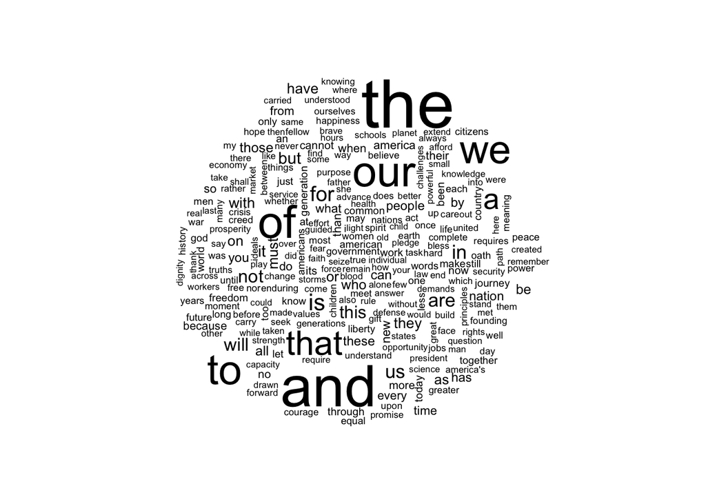

   ```r
   plot(obamadfm)
   ```

   Try producing that plot without the stopwords. See `removeFeatures()` to remove stopwords from the dfm object directly, or supply the `ignoredFeatures` argument to `dfm()`.

   ```r
   obamadfm2 <- removeFeatures(obamadfm, stopwords("english"))
   ```

   ```
   ## removed 107 features, from 174 supplied feature types
   ```

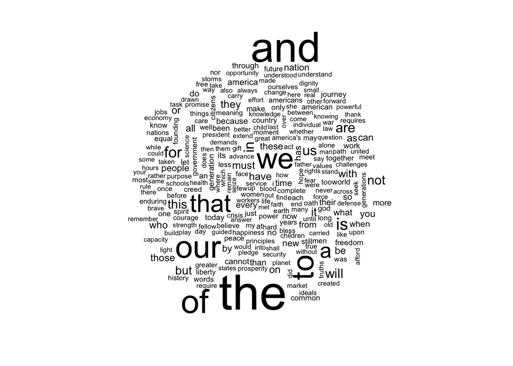

   ```r
   plot(obamadfm)
   ```

   ```r
   # other method:
   obamadfm2a <- dfm(subset(inaugCorpus, President=="Obama"),
                     ignoredFeatures = stopwords("english"))
   ```

   ```
   ## Creating a dfm from a corpus ...
   ##    ... lowercasing
   ##    ... tokenizing
   ##    ... indexing documents: 2 documents
   ##    ... indexing features: 1,337 feature types
   ##    ... removed 107 features, from 174 supplied feature types
   ##    ... created a 2 x 1230 sparse dfm
   ##    ... complete.
   ## Elapsed time: 0.039 seconds.
   ```

   ```r
   all.equal(obamadfm2, obamadfm2a)
   ```

   ```
   ## [1] TRUE
   ```

7. **Preparing and pre-processing texts**
   1. “Cleaning”" texts

      It is common to “clean” texts before processing, usually by removing punctuation, digits, and converting to lower case. Look at the documentation for `toLower()` and use the command on the `exampleString` text (you can load this from **quantedaData** using `data(exampleString)`. Can you think of cases where cleaning could introduce homonymy?

      ```r
      exampleString
      ```

      ```
      ## [1] "Instead we have a Fine Gael-Labour Party Government, coming into power promising real change but slavishly following the previous Government’s policy. That policy has been dictated by the IMF, the EU and the ECB not to bail out the Irish people but to salvage German, French, British banks an…
      ```

      ```r
      toLower(exampleString)
      ```

      ```
      ## [1] "instead we have a fine gael-labour party government, coming into power promising real change but slavishly following the previous government’s policy. that policy has been dictated by the imf, the eu and the ecb not to bail out the irish people but to salvage german, french, british banks an…
      ```

   2. Tokenizing texts

      In order to count word frequencies, we first need to split the text into words through a process known as **tokenization**. Look at the documentation for **quanteda**’s `tokenize()` function. Use the `tokenize` command on `exampleString`, and examine the results. Are there cases where it is unclear where the boundary between two words lies? You can experiment with the options to `tokenize`.

      ```r
      tokenize(toLower(exampleString))
      ```

      ```
      ## [[1]]
      ##   [1] "instead"       "we"            "have"          "a"
      ##   [5] "fine"          "gael"          "-"             "labour"
      ##   [9] "party"         "government"    ","             "coming"
      ##  [13] "into"          "power"         "promising"     "real"
      ##  [17] "change"        "but"           "slavishly"     "following"
      ##  [21] "the"           "previous"      "government’s"  "policy"
      ##  [25] "."             "that"          "policy"        "has"
      ##  [29] "been"          "dictated"      "by"            "the"
      ##  [33] "imf"           ","             "the"           "eu"
      ##  [37] "and"           "the"           "ecb"           "not"
      ##  [41] "to"            "bail"          "out"           "the"
      ##  [45] "irish"         "people"        "but"           "to"
      ##  [49] "salvage"       "german"        ","             "french"
      ##  [53] ","             "british"       "banks"         "and"
      ```

      [output cut: 122 more lines]

      ```r
      tokenize(toLower(exampleString), removePunct = TRUE, removeNumbers = TRUE)
      ```

      ```
      ## [[1]]
      ##   [1] "instead"       "we"            "have"          "a"
      ##   [5] "fine"          "gael-labour"   "party"         "government"
      ##   [9] "coming"        "into"          "power"         "promising"
      ##  [13] "real"          "change"        "but"           "slavishly"
      ##  [17] "following"     "the"           "previous"      "government’s"
      ##  [21] "policy"        "that"          "policy"        "has"
      ##  [25] "been"          "dictated"      "by"            "the"
      ##  [29] "imf"           "the"           "eu"            "and"
      ##  [33] "the"           "ecb"           "not"           "to"
      ##  [37] "bail"          "out"           "the"           "irish"
      ##  [41] "people"        "but"           "to"            "salvage"
      ##  [45] "german"        "french"        "british"       "banks"
      ##  [49] "and"           "those"         "of"            "other"
      ##  [53] "countries"     "from"          "their"         "disastrous"
      ```

      [output cut: 112 more lines]

      Try tokenizing the sentences from `exampleString` into sentences, using `tokenize(x, what = "sentence")`.

      ```r
      tokenize(exampleString, what = "sentence")
      ```

      ```
      ## [[1]]
      ##  [1] "Instead we have a Fine Gael-Labour Party Government, coming into power promising real change but slavishly following the previous Government’s policy."
      ##  [2] "That policy has been dictated by the IMF, the EU and the ECB not to bail out the Irish people but to salvage German, French, British banks and those of other countries from their disastrous and frenzied embrace of Irish bankers and speculators in the Irish property market bubble."
      ##  [3] "It is criminal that an Irish Government would ever slavishly agree to make a vassal State of the Republic of Ireland and its people, to squeeze tribute from our people to save the capitalist banks of Europe and in doing so destroy the lives of hundreds of thousands of our people now plunged…
      ##  [4] "In this budget and the past four years the austerity policy means €25 billion has been reefed out of the Irish economy in pursuit of a policy of cringing acceptance of the diktats of the financial markets."
      ##  [5] "Can this Government not see that, not only is this immoral and unjust in the extreme, it is decimating the domestic economy?"
      ##  [6] "As we are tired of pointing out, if we savage the ability of the majority of our people to purchase goods and utilise services, then tens of thousands of workers depending on this demand for their jobs will be thrown on the scrapheap of unemployment and, tragically, that is what is happenin…
      ##  [7] "All the key indicators in the domestic economy show the abject failure of austerity."
      ##  [8] "Private investment has collapsed, VAT receipts are more than €400 million behind and unemployment has risen by thousands since this Government entered office."
      ##  [9] "Much is made of the growth in exports."
      ## [10] "Every job in the export sector is vital and we defend it but the type of investment and the capital intensive nature of the investment that goes into exports means that it is not where the hundreds of thousands of jobs we need will be created in the next period of years."
      ## [11] "On the other hand, taking €670 million from the pockets of ordinary people through the VAT increases and taking other money in the cuts in child benefit and elsewhere will further add to the downward spiral of austerity."
      ## [12] "The interest relief for householders who are trapped in the nightmare of negative equity and extortionate monthly mortgage payments will be welcomed to a degree but is dismally inadequate."
      ## [13] "That generation of workers who are trapped in this nightmare are victims of the extortion perpetrated on them in the housing market by the immoral speculators legislated for by Fianna Fáil and the PDs."
      ## [14] "The huge proportion of their incomes that continues to go to the banks massively dislocates the economy."
      ## [15] "Otherwise those funds would be going to the purchase of goods and services in the domestic economy, stimulating demand and sustaining tens of thousands of jobs for tens of thousands of people who are now on the dole, unfortunately."
      ##
      ## attr(,"class")
      ## [1] "tokenizedTexts" "list"
      ```

   3. Stemming.

      Stemming removes the suffixes using the Porter stemmer, found in the **SnowballC** library. The **quanteda** function to invoke the stemmer is `wordstem`. Apply stemming to the `exampleString` and examine the results. Why does it not appear to work, and what do you need to do to make it work? How would you apply this to the sentence-segmented vector?

      ```r
      # wordstem(exampleString) # fails
      wordstem(tokenize(toLower(exampleString), removePunct = TRUE))
      ```

      ```
      ## [[1]]
      ##   [1] "instead"     "we"          "have"        "a"           "fine"
      ##   [6] "gael-labour" "parti"       "govern"      "come"        "into"
      ##  [11] "power"       "promis"      "real"        "chang"       "but"
      ##  [16] "slavishli"   "follow"      "the"         "previou"     "government’"
      ##  [21] "polici"      "that"        "polici"      "ha"          "been"
      ##  [26] "dictat"      "by"          "the"         "imf"         "the"
      ##  [31] "eu"          "and"         "the"         "ecb"         "not"
      ##  [36] "to"          "bail"        "out"         "the"         "irish"
      ##  [41] "peopl"       "but"         "to"          "salvag"      "german"
      ##  [46] "french"      "british"     "bank"        "and"         "those"
      ##  [51] "of"          "other"       "countri"     "from"        "their"
      ##  [56] "disastr"     "and"         "frenzi"      "embrac"      "of"
      ##  [61] "irish"       "banker"      "and"         "specul"      "in"
      ##  [66] "the"         "irish"       "properti"    "market"      "bubbl"
      ```

      [output cut: 88 more lines]

   4. Applying “pre-processing” to the creation of a **dfm**.

      **quanteda**’s `dfm()` function makes it wasy to pass the cleaning arguments to clean, which are executed as part of the tokenization implemented by `dfm()`. Compare the steps required in a similar text preparation package, [**tm**](http://cran.r-project.org/package=tm):

      ```r
      require(tm)
      data(crude)
      crude <- tm_map(crude, content_transformer(tolower))
      crude <- tm_map(crude, removePunctuation)
      crude <- tm_map(crude, removeNumbers)
      crude <- tm_map(crude, stemDocument)
      tdm <- TermDocumentMatrix(crude)

      # same in quanteda
      crudeCorpus <- corpus(crude)
      crudeDfm <- dfm(crudeCorpus)
      ```

      ```
      ## Creating a dfm from a corpus ...
      ##    ... lowercasing
      ##    ... tokenizing
      ##    ... indexing documents: 20 documents
      ##    ... indexing features: 973 feature types
      ##    ... created a 20 x 973 sparse dfm
      ##    ... complete.
      ## Elapsed time: 0.01 seconds.
      ```

      Inspect the dimensions of the resulting objects, including the names of the words extracted as features. It is also worth comparing the structure of the document-feature matrixes returned by each package. **tm** uses the [slam](http://cran.r-project.org/web/packages/slam/index.html) *simple triplet matrix* format for representing a [sparse matrix](http://en.wikipedia.org/wiki/Sparse_matrix).

      It is also – in fact almost always – useful to inspect the structure of this object:

      ```r
      str(tdm)
      ```

      ```
      ## List of 6
      ##  $ i       : int [1:1954] 49 86 110 148 166 167 178 183 184 195 ...
      ##  $ j       : int [1:1954] 1 1 1 1 1 1 1 1 1 1 ...
      ##  $ v       : num [1:1954] 1 2 1 1 1 1 2 1 1 2 ...
      ##  $ nrow    : int 943
      ##  $ ncol    : int 20
      ##  $ dimnames:List of 2
      ##   ..$ Terms: chr [1:943] "abdulaziz" "abil" "abl" "about" ...
      ##   ..$ Docs : chr [1:20] "127" "144" "191" "194" ...
      ##  - attr(*, "class")= chr [1:2] "TermDocumentMatrix" "simple_triplet_matrix"
      ##  - attr(*, "weighting")= chr [1:2] "term frequency" "tf"
      ```

      THis indicates that we can extract the names of the words from the **tm** TermDocumentMatrix object by getting the rownames from inspecting the tdm:

      ```r
      head(tdm$dimnames$Terms, 20)
      ```

      ```
      ##  [1] "abdulaziz" "abil"      "abl"       "about"     "abov"
      ##  [6] "above"     "abroad"    "accept"    "accord"    "across"
      ## [11] "act"       "activity"  "add"       "added"     "address"
      ## [16] "adher"     "advantag"  "advisers"  "after"     "again"
      ```

      Compare this to the results of the same operations from **quanteda**. To get the “words” from a quanteda object, you can use the `features()` function:

      ```r
      features_quanteda <- features(crudeDfm)
      head(features_quanteda, 20)
      ```

      ```
      ##  [1] "diamond"  "shamrock" "corp"     "said"     "that"     "effect"
      ##  [7] "today"    "it"       "had"      "cut"      "contract" "price"
      ## [13] "for"      "crude"    "oil"      "by"       "dlrs"     "a"
      ## [19] "barrel"   "the"
      ```

      ```r
      str(crudeDfm)
      ```

      ```
      ## Formal class 'dfmSparse' [package "quanteda"] with 9 slots
      ##   ..@ settings :List of 1
      ##   .. ..$ : NULL
      ##   ..@ weighting: chr "frequency"
      ##   ..@ smooth   : num 0
      ##   ..@ Dim      : int [1:2] 20 973
      ##   ..@ Dimnames :List of 2
      ##   .. ..$ docs    : chr [1:20] "127" "144" "191" "194" ...
      ##   .. ..$ features: chr [1:973] "diamond" "shamrock" "corp" "said" ...
      ##   ..@ i        : int [1:2172] 0 0 0 10 17 0 1 2 3 4 ...
      ##   ..@ p        : int [1:974] 0 1 2 5 25 36 41 48 65 69 ...
      ##   ..@ x        : num [1:2172] 2 1 1 3 1 3 11 1 1 3 ...
      ##   ..@ factors  : list()
      ```

      What proportion of the `crudeDfm` are zeros? Compare the sizes of `tdm` and `crudeDfm` using the `object.size()` function.

      ```r
      # note that length() applied to a matrix gives the total number of cells
      sum(crudeDfm == 0) / length(crudeDfm)
      ```

      ```
      ## [1] 0.8883864
      ```

8. **Keywords-in-context**
   1. **quanteda** provides a keyword-in-context function that is easily usable and configurable to explore texts in a descriptive way. Type `?kwic` to view the documentation.
   2. For the Irish budget debate speeches corpus for the year 2010, called `ie2010Corpus`, experiment with the `kwic` function, following the syntax specified on the help page for `kwic`. `kwic` can be used either on a character vector or a corpus object. What class of object is returned? Try assigning the return value from `kwic` to a new object and then examine the object by clicking on it in the environment pane in RStudio (or using the inspection method of your choice).

      ```r
      myKwic <- kwic(inaugCorpus, "Christmas")
      str(myKwic)
      ```

      ```
      ## Classes 'kwic' and 'data.frame': 1 obs. of  3 variables:
      ##  $ preword : chr "the moon's gray surface on"
      ##  $ word    : chr "Christmas"
      ##  $ postword: chr "Eve, they spoke to us"
      ```

   3. Use the `kwic` function to discover the context of the word “clean”. Is this associated with environmental policy?

      ```r
      kwic(inaugCorpus, "clean")
      ```

      ```
      ##                                                                 preword
      ##     [1913-Wilson, 672]                          affairs. Our duty is to
      ##    [1913-Wilson, 1404]                                   be if we had a
      ## [1933-Roosevelt, 1745]                  precious moral values; with the
      ##      [1973-Nixon, 711]         better housing, better transportation, a
      ##    [1997-Clinton, 468] communities, better educational opportunities, a
      ##     [2009-Obama, 1681]                      your farms flourish and let
      ##                            word                               postword
      ##     [1913-Wilson, 672] cleanse, to reconsider, to restore, to
      ##    [1913-Wilson, 1404]  clean   sheet of paper to write
      ## [1933-Roosevelt, 1745]    clean satisfaction that comes from the
      ##      [1973-Nixon, 711]  cleaner environment -- to restore respect
      ##    [1997-Clinton, 468]  cleaner environment. Problems that once seemed
      ##     [2009-Obama, 1681]    clean waters flow; to nourish starved
      ```

      ```r
      str(myKwic)
      ```

      ```
      ## Classes 'kwic' and 'data.frame': 1 obs. of  3 variables:
      ##  $ preword : chr "the moon's gray surface on"
      ##  $ word    : chr "Christmas"
      ##  $ postword: chr "Eve, they spoke to us"
      ```

   4. By default, kwic explores all words related to the word, since it interprets the pattern as a “regular expression”. What if we wanted to see only the literal, entire word “disaster”? Hint: Look at the arguments using `?kwic`.

      ```r
      kwic(inaugCorpus, "disaster", wholeword = TRUE)
      ```

      ```
      ##                                                 preword     word
      ##  [1837-VanBuren, 2322] prominent sources of discord and disaster
      ##  [1881-Garfield, 1375]          by which to measure the disaster
      ## [1937-Roosevelt, 1242]          that the pall of family disaster
      ##      [2005-Bush, 1813]          good and the victims of disaster
      ##                                        postword
      ##  [1837-VanBuren, 2322] supposed to lurk in our
      ##  [1881-Garfield, 1375] that may be brought upon
      ## [1937-Roosevelt, 1242] hangs over them day by
      ##      [2005-Bush, 1813] are given hope and the
      ```

      ```r
      str(myKwic)
      ```

      ```
      ## Classes 'kwic' and 'data.frame': 1 obs. of  3 variables:
      ##  $ preword : chr "the moon's gray surface on"
      ##  $ word    : chr "Christmas"
      ##  $ postword: chr "Eve, they spoke to us"
      ```

      ```r
      ieDfm <- dfm(inaugCorpus)
      ```

      ```
      ## Creating a dfm from a corpus ...
      ##    ... lowercasing
      ##    ... tokenizing
      ##    ... indexing documents: 57 documents
      ##    ... indexing features: 9,214 feature types
      ##    ... created a 57 x 9214 sparse dfm
      ##    ... complete.
      ## Elapsed time: 0.211 seconds.
      ```

   2. Examine the most frequent word features using `topfeatures()`. What are the five most frequent word in the corpus?

      ```r
      topfeatures(ieDfm)
      ```

      ```
      ##   the    of   and    to    in     a   our  that    we    be
      ## 10011  7055  5233  4490  2771  2231  2134  1780  1693  1469
      ```

   3. **quanteda** provides a function to count syllables in a word — `syllables`. Try the function at the prompt. The code below will apply this function to all the words in the corpus, to give you a count of the total syllables in the corpus.

      ```r
      # count syllables from texts in the 2010 speech corpus
      textSyls <- syllables(texts(ie2010Corpus))
      # sum the syllable counts
      totalSyls <- sum(textSyls)
      ```

      How would you get the total syllables per text?

      ```r
      textSyls
      ```

      ```
      ##       2010_BUDGET_01_Brian_Lenihan_FF
      ##                                 12862
      ##      2010_BUDGET_02_Richard_Bruton_FG
      ##                                  5924
      ##        2010_BUDGET_03_Joan_Burton_LAB
      ##                                  8696
      ##       2010_BUDGET_04_Arthur_Morgan_SF
      ##                                  9958
      ##         2010_BUDGET_05_Brian_Cowen_FF
      ##                                  9756
      ##          2010_BUDGET_06_Enda_Kenny_FG
      ##                                  5863
      ##     2010_BUDGET_07_Kieran_ODonnell_FG
      ##                                  3003
      ##      2010_BUDGET_08_Eamon_Gilmore_LAB
      ##                                  5794
      ##    2010_BUDGET_09_Michael_Higgins_LAB
      ##                                  1741
      ##       2010_BUDGET_10_Ruairi_Quinn_LAB
      ##                                  1729
      ##     2010_BUDGET_11_John_Gormley_Green
      ##                                  1438
      ##       2010_BUDGET_12_Eamon_Ryan_Green
      ##                                  2190
      ##     2010_BUDGET_13_Ciaran_Cuffe_Green
      ##                                  1730
      ## 2010_BUDGET_14_Caoimhghin_OCaolain_SF
      ##                                  5549
      ```

      **`textSylls` is already the vector of syllables from the vector of budget texts.**
10. **Lexical Diversity over Time**
    1. We can plot the type-token ratio of the Irish budget speeches over time. To do this, begin by extracting a subset of iebudgets that contains only the first speaker from each year:

       ```r
       data(iebudgetsCorpus, package = "quantedaData")
       finMins <- subset(iebudgetsCorpus, number=="01")
       tokeninfo <- summary(finMins)
       ```

       ```
       ## Corpus consisting of 6 documents.
       ##
       ##                                Text Types Tokens Sentences year    debate
       ##       2008_BUDGET_01_Brian_Cowen_FF  1852   8975       463 2008    BUDGET
       ##     2009_BUDGET_01_Brian_Lenihan_FF  1758   7828       444 2009    BUDGET
       ##  2009_BUDGETSUP_01_Brian_Lenihan_FF  1730   7678       405 2009 BUDGETSUP
       ##     2010_BUDGET_01_Brian_Lenihan_FF  1754   7916       404 2010    BUDGET
       ##     2011_BUDGET_01_Brian_Lenihan_FF  1621   7233       387 2011    BUDGET
       ##    2012_BUDGET_01_Michael_Noonan_FG  1591   6578       302 2012    BUDGET
       ##  number namefirst namelast party
       ##      01     Brian    Cowen    FF
       ##      01     Brian  Lenihan    FF
       ##      01     Brian  Lenihan    FF
       ##      01     Brian  Lenihan    FF
       ##      01     Brian  Lenihan    FF
       ##      01   Michael   Noonan    FG
       ##
       ## Source:  /Users/kbenoit/Dropbox/QUANTESS/quantedaData_kenlocal_gh/* on x86_64 by kbenoit.
       ## Created: Sat Nov 15 18:32:54 2014.
       ## Notes:   .
       ```

       Note the quotation marks around the value for `number`. Why are these required here?  
       **Because it is a character data type, not numeric.**
    2. Get the type-token ratio for each text from this subset, and plot the resulting vector of TTRs as a function of the year. Hint: See `?lexdiv`.

       ```r
       (TTR <- lexdiv(dfm(finMins, verbose = FALSE), measure = "TTR"))
       ```

       ```
       ##      2008_BUDGET_01_Brian_Cowen_FF    2009_BUDGET_01_Brian_Lenihan_FF
       ##                          0.1953360                          0.2163158
       ## 2009_BUDGETSUP_01_Brian_Lenihan_FF    2010_BUDGET_01_Brian_Lenihan_FF
       ##                          0.2170377                          0.2142487
       ##    2011_BUDGET_01_Brian_Lenihan_FF   2012_BUDGET_01_Michael_Noonan_FG
       ##                          0.2177614                          0.2376794
       ```

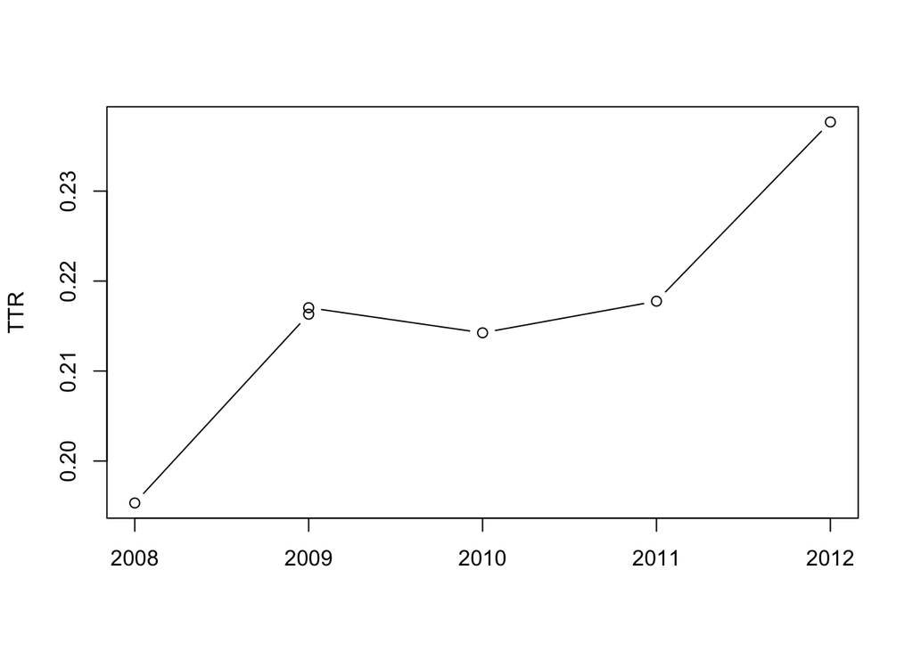

       ```r
       plot(docvars(finMins, "year"), TTR, xlab = "", type = "b")
       ```

11. **Document and word associations**
    1. Load the presidential inauguration corpus selecting from 1900-1950, and create a dfm from this corpus.

       ```r
       presDfm <- dfm(subset(inaugCorpus, Year >= 1900 & Year <= 1950))
       ```

       ```
       ## Creating a dfm from a corpus ...
       ##    ... lowercasing
       ##    ... tokenizing
       ##    ... indexing documents: 13 documents
       ##    ... indexing features: 4,264 feature types
       ##    ... created a 13 x 4264 sparse dfm
       ##    ... complete.
       ## Elapsed time: 0.059 seconds.
       ```

    2. Measure the term similarities for the following words: *economy*, *health*, *women*.

       ```r
       simils <- similarity(presDfm, c("economy", "health", "women"))
       ```

       ```
       ## Note: method with signature 'CsparseMatrix#Matrix#missing#replValue' chosen for function '[<-',
       ##  target signature 'dfmSparse#ngCMatrix#missing#numeric'.
       ##  "Matrix#nsparseMatrix#missing#replValue" would also be valid
       ```

       ```r
       head(simils)
       ```

       ```
       ## $economy
       ##        property          expect           array         finding
       ##          0.9498          0.8727          0.8506          0.8506
       ##         effects         applied     deliverance     manifesting
       ##          0.8506          0.8506          0.8506          0.8506
       ## conscientiously      rearranged
       ##          0.8506          0.8506
       ##
       ## $women
       ##         come       vision          age        using     impotent
       ##       0.8905       0.8002       0.7777       0.7738       0.7738
       ## achievements       morals     heedless         cool       hearts
       ##       0.7738       0.7738       0.7738       0.7738       0.7731
       ##
       ## $health
       ##          health instrumentality          system      critically
       ##          1.0000          0.9720          0.9425          0.9421
       ##       conceived          groups          beauty     helpfulness
       ##          0.9421          0.9421          0.9421          0.9421
       ##        moreover         delayed
       ##          0.9421          0.9421
       ```

12. **Working with dictionaries**

    Dictionaries are named lists, consisting of a “key” and a set of entries defining the equivalence class for the given key. To create a simple dictionary of parts of speech, for instance we could define a dictionary consisting of articles and conjunctions, using:

    ```r
    posDict <- dictionary(list(articles = c("the", "a", "and"),
                               conjunctions = c("and", "but", "or", "nor", "for", "yet", "so")))
    ```

    To let this define a set of features, we can use this dictionary when we create a `dfm`, for instance:

    ```r
    posDfm <- dfm(inaugCorpus, dictionary = posDict)
    ```

    ```
    ## Creating a dfm from a corpus ...
    ##    ... lowercasing
    ##    ... tokenizing
    ##    ... indexing documents: 57 documents
    ##    ... indexing features: 9,214 feature types
    ##    ... applying a dictionary consisting of 2 keys
    ##    ... created a 57 x 2 sparse dfm
    ##    ... complete.
    ## Elapsed time: 0.24 seconds.
    ```

    ```r
    posDfm[1:10,]
    ```

    ```
    ## Document-feature matrix of: 10 documents, 2 features.
    ## 10 x 2 sparse Matrix of class "dfmSparse"
    ##                  features
    ## docs              articles conjunctions
    ##   1789-Washington      178           73
    ##   1793-Washington       15            4
    ##   1797-Adams           344          192
    ##   1801-Jefferson       232          109
    ##   1805-Jefferson       256          126
    ##   1809-Madison         166           63
    ##   1813-Madison         169           63
    ##   1817-Monroe          458          174
    ##   1821-Monroe          577          195
    ##   1825-Adams           448          150
    ```

    Weight the `posDfm` by term frequency using `weight()`, and plot the values of articles and conjunctions (actually, here just the coordinating conjunctions) across the speeches. (**Hint:** you can use `docvars(inaugCorpus, "Year"))` for the *x*-axis.)

    ```r
    posDfm <- weight(posDfm, "relFreq")
    posDfm[1:10,]
    ```

    ```
    ## Document-feature matrix of: 10 documents, 2 features.
    ## 10 x 2 sparse Matrix of class "dfmSparse"
    ##                  features
    ## docs               articles conjunctions
    ##   1789-Washington 0.7091633    0.2908367
    ##   1793-Washington 0.7894737    0.2105263
    ##   1797-Adams      0.6417910    0.3582090
    ##   1801-Jefferson  0.6803519    0.3196481
    ##   1805-Jefferson  0.6701571    0.3298429
    ##   1809-Madison    0.7248908    0.2751092
    ##   1813-Madison    0.7284483    0.2715517
    ##   1817-Monroe     0.7246835    0.2753165
    ##   1821-Monroe     0.7474093    0.2525907
    ##   1825-Adams      0.7491639    0.2508361
    ```

    Is the distribution of normalized articles and conjunctions relatively constant across years, as you would expect?

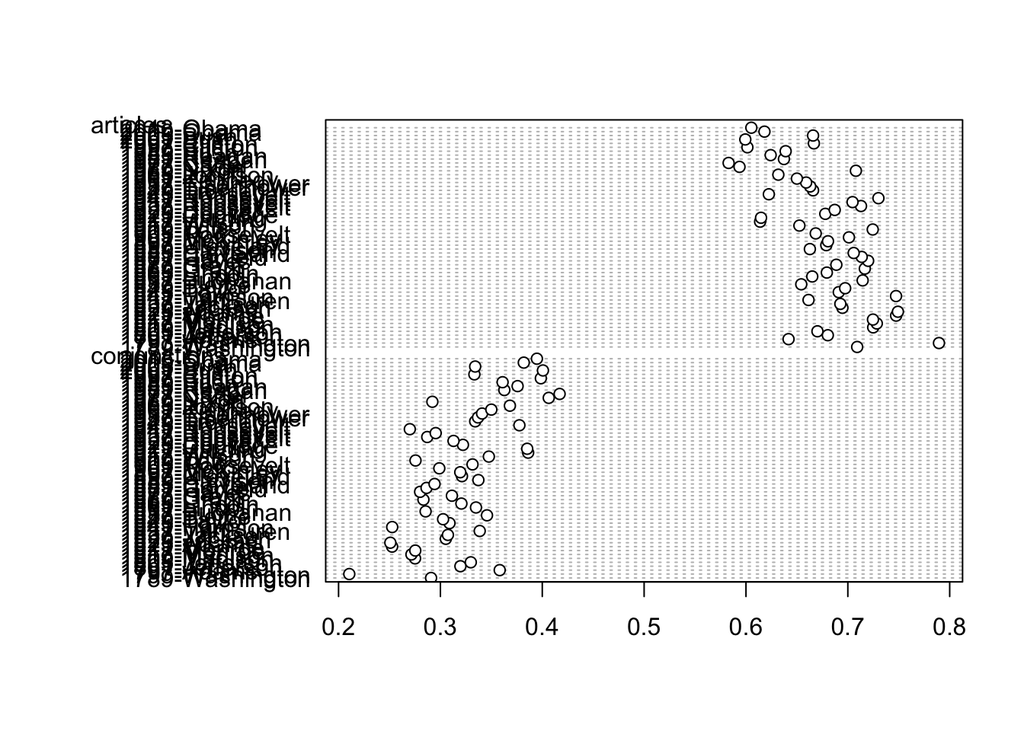

    ```r
    dotchart(as.matrix(posDfm))
    ```

13. Settle a Scrabble word value dispute.

    Look up the Scrabble values of “aerie” and “queue”. And ask yourself how can an English word have five letters and just one consonant?? It’s downright **eerie**.

    ```r
    scrabble(c("aerie", "queue", "eerie"))
    ```

    ```
    ## [1]  5 14  5
    ```